# Criminal Urbana (XXI)

2023-02-22

## Dataset & Objectives

### Dataset

- originally **486708** records of crimes in Urbana 1980-2022
- Narrowed down to 2000-2022, some crimes removed
- **79313** records left

### Objectives

1. Visualize safe walking/living areas by creating maps
2. Analyze time series of different crimes: are rates going down?

## Overview (2000-2022)

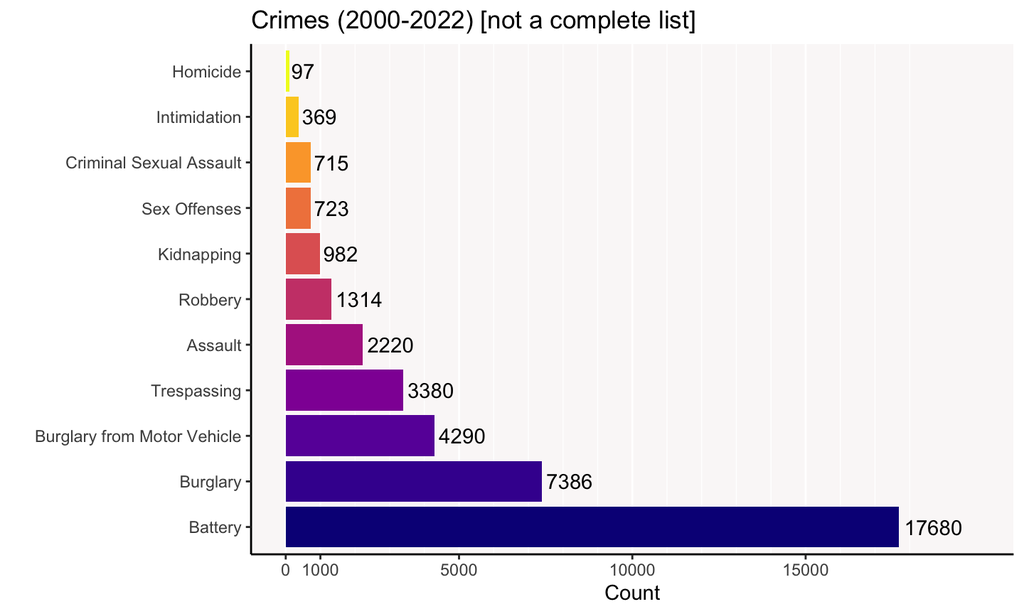

## Different crimes by time - pie chart

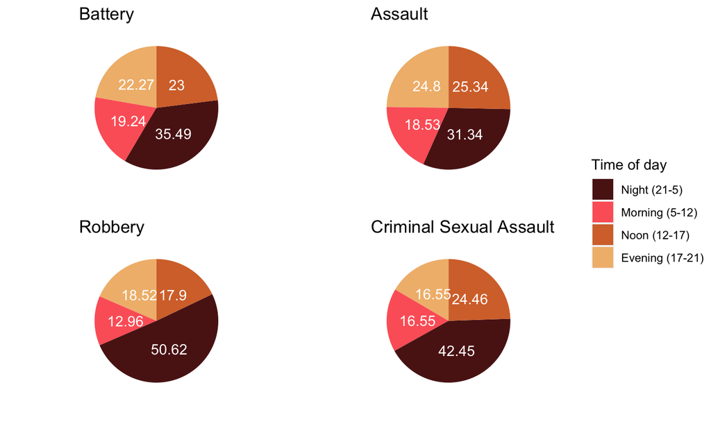

## Map of Robberies (2018-2022)

[interactive chart not shown]

## Map of Criminal SA’s (2018-2022)

[interactive chart not shown]

- 4 at Carle Emergency Care Unit - ’20, ’21 (x2), ’22
- 6 at Vinewood Apartments - ’18, ’19, ’20 (x2), ’21, ’22

## The ultimate map (2022)

[interactive chart not shown]

## Yearly homicides - plot (2000-2022)

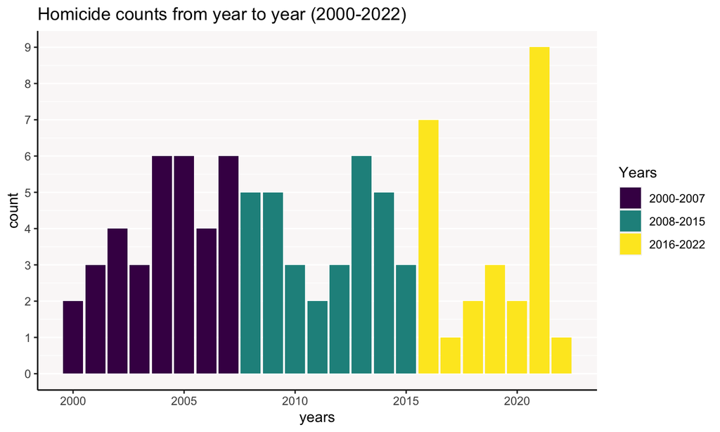

## Homicides by time - pie chart

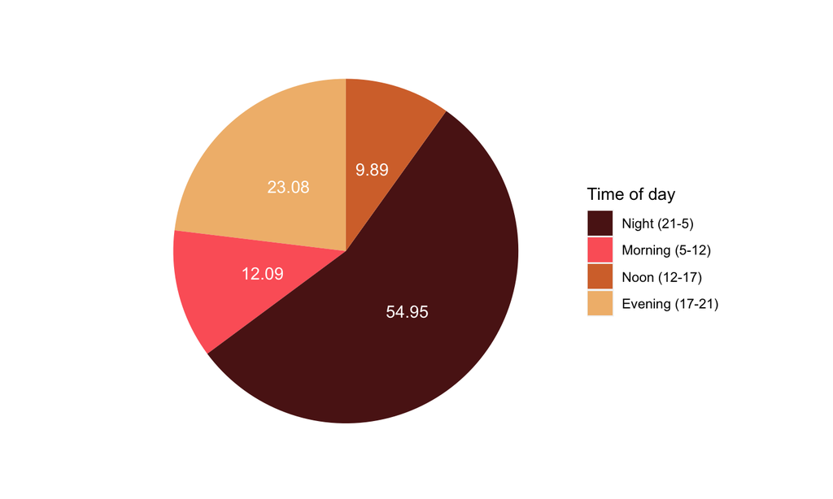

## Map of homicides (2000-2022)

[interactive chart not shown]

- 6 at 2000 Vawter St - ’08, ’09, ’14, ’16(x2), ’18 [(article)](https://newschannel20.com/news/local/deadly-shooting-in-urbana)

## 2000 Vawter St

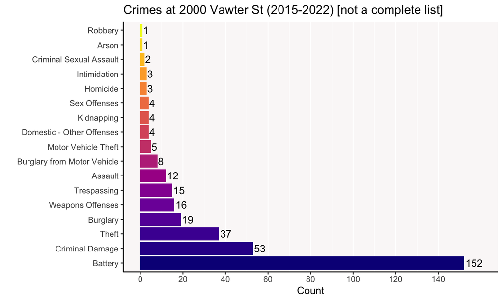

- 3 more homicides in 2008-2014

## 2000 Vawter St (II)

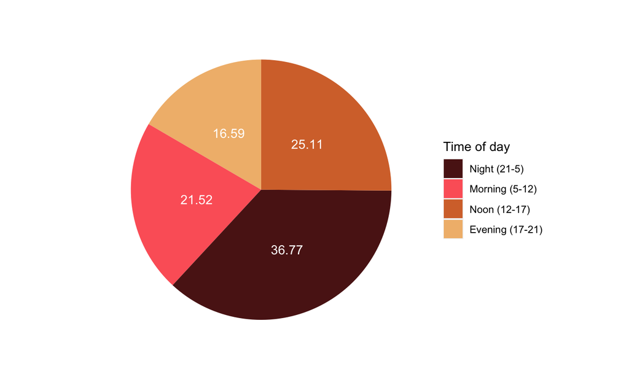

## Vinewood Apartments (1200 S Vine St)

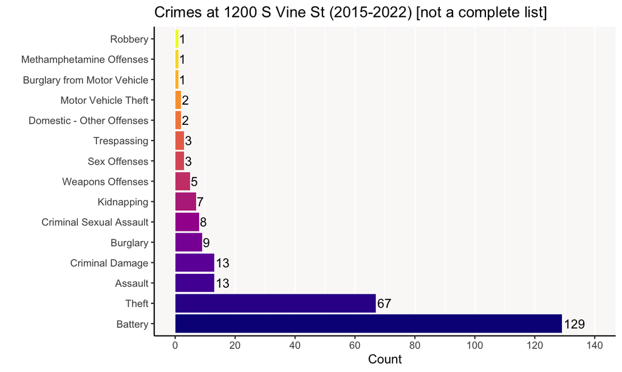

## Vinewood Apartments (II)

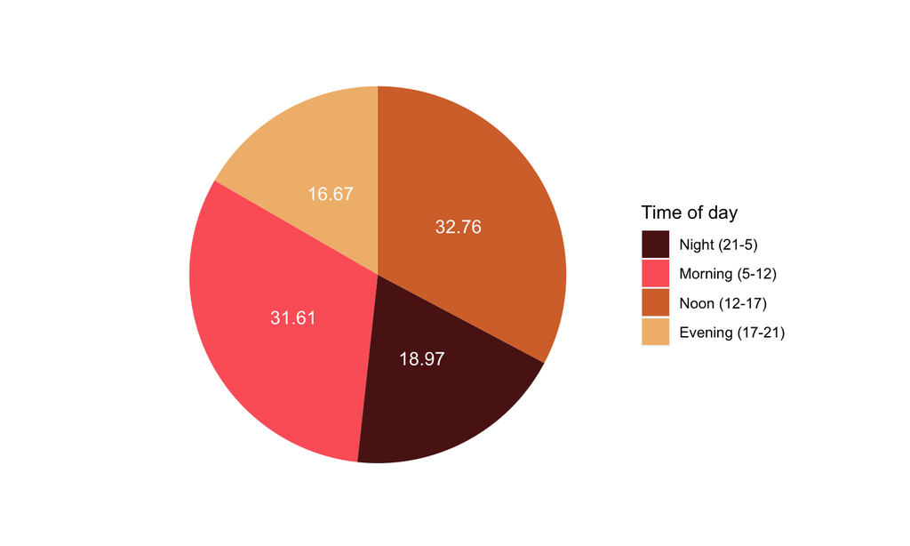

## But what is the actual intertemporal structure?

## Detailed time series of different crimes

- Homicides - too few observations

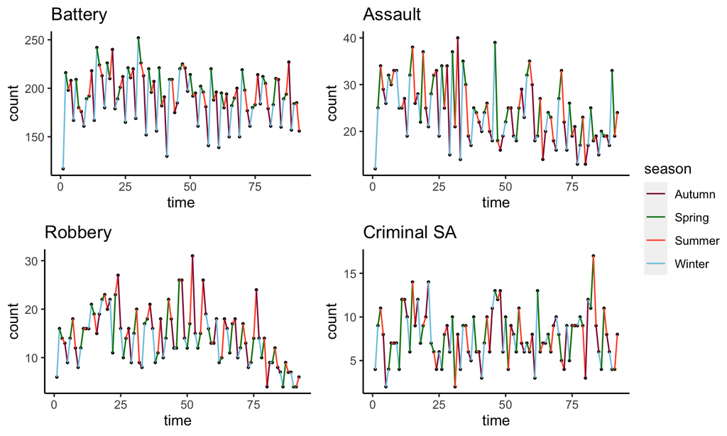

## ARMA models & Stationarity

1. \(ARMA(p,q)\) w/ drift & trend: \(\ X_t=\mu+\delta t+\Sigma_{i=1}^p \theta_iX_{t-i}+\varepsilon_t+\Sigma_{j=1}^p \phi_j\varepsilon_{t-j}\)
2. Weakly stationarity:
   - \(\mathbb{E}(X_t) \perp t, \forall t\)
   - \(\text{Cov}(X_t,X_{t+l})=\gamma(l) \perp t, \forall t\)
   - trend stationary: stationary after detrending
3. (2.) for \(ARMA(p,q)\) guaranteed by \(\Sigma_{i=1}^p |\theta_i|<1\)
4. \(ADF\) tests (3.), selecting \(p, q\) with \(AIC\):
5. \(AIC=-2\ln L(p,q)+2(p+q+2+\mathbf{1}_{\delta\neq 0})\rightarrow \min_{p,q}\)

## ADF test for stationarity

- Battery & Criminal SA
  - weakly **stationary** at \(0.1\%\) level
  - 1 lag selected by AIC
- Assault & Robbery
  - trend **stationary** at \(0.1\%\) level
  - significant negative time trend
  - 1 lag selected by AIC

## Chosen ARMA models (using AIC):

- Battery: \(\text{ARMA}(1^{0.1\%},1^{0.1\%})\), w/o trend

\(X_t=192.2-0.999X_{t-1}+\varepsilon_t+0.978\varepsilon_{t-1}\)

- Assault: MA(\(1^{10\%}\)) w/ trend\(^{0.1\%}\)

\(X_t=29.1-0.107t+\varepsilon_t-0.178\varepsilon_{t-1}\)

- Robbery: MA(\(1^{0.1\%}\)) w/ trend\(^{1\%}\)

\(X_t=17.5-0.071t+\varepsilon_t+0.49\varepsilon_{t-1}\)

- Criminal SA: AR(\(1^{>10\%}\)) w/o trend

\(X_t=7.76+0.1X_{t-1}+\varepsilon_t\)

## Further research directions

- Consider more complicated TS models
- Any areas that are more dangerous? (clusterings)
- Including external factors (e.g., city population)
- Predicting time and coordinates of a crime